# Descriptive Statistics

[Sushank Pokhrel (Homepage)](https://sushank.com.np)

### 1. Loading the package `tidyverse` and Dataset.

```r
library(tidyverse)
```

In R, we have iris dataset.

```r
iris
```

```
##     Sepal.Length Sepal.Width Petal.Length Petal.Width    Species
## 1            5.1         3.5          1.4         0.2     setosa
## 2            4.9         3.0          1.4         0.2     setosa
## 3            4.7         3.2          1.3         0.2     setosa
## 4            4.6         3.1          1.5         0.2     setosa
## 5            5.0         3.6          1.4         0.2     setosa
## 6            5.4         3.9          1.7         0.4     setosa
## 7            4.6         3.4          1.4         0.3     setosa
## 8            5.0         3.4          1.5         0.2     setosa
## 9            4.4         2.9          1.4         0.2     setosa
## 10           4.9         3.1          1.5         0.1     setosa
## 11           5.4         3.7          1.5         0.2     setosa
## 12           4.8         3.4          1.6         0.2     setosa
## 13           4.8         3.0          1.4         0.1     setosa
## 14           4.3         3.0          1.1         0.1     setosa
```

[output cut: 136 more lines]

```r
?iris
```

```
## starting httpd help server ... done
```

Opens the R documentation for the iris dataset. This is useful for understanding the dataset’s structure, variables, and background information.

```r
iris_data <- iris
```

Creates a copy of the iris dataset named iris_data. This is useful if you plan to manipulate the dataset but want to preserve the original for reference.

```r
names(iris_data)
```

```
## [1] "Sepal.Length" "Sepal.Width"  "Petal.Length" "Petal.Width"  "Species"
```

names(iris_data): Displays the column names of the dataset to help understand its structure.

### 2. Basic Statistical Calculations

Following functions are used in basic calculations.

- `mean()`: Calculates the average value.
- `median()`: Finds the middle value when data is sorted.
- `max()` and `min()`: Identify the maximum and minimum values, respectively.
- `sd()`: Computes the standard deviation, a measure of data spread.
- `range()`: Returns the minimum and maximum values as a vector.
- `quantile()`: Calculates quantiles (e.g., 25th, 50th, and 75th percentiles).
- `summary()`: Provides a comprehensive summary, including minimum, maximum, median, mean, and quantiles.

```r
mean(iris_data$Sepal.Length) # mean
```

```
## [1] 5.843333
```

```r
median(iris_data$Sepal.Length) # median
```

```
## [1] 5.8
```

```r
max(iris_data$Sepal.Length)  # max value
```

```
## [1] 7.9
```

```r
min(iris_data$Sepal.Length) # min value
```

```
## [1] 4.3
```

```r
sd(iris_data$Sepal.Length) # standard deviation
```

```
## [1] 0.8280661
```

```r
range(iris_data$Sepal.Length) # range
```

```
## [1] 4.3 7.9
```

```r
quantile(iris_data$Sepal.Length) # quartiles
```

```
##   0%  25%  50%  75% 100%
##  4.3  5.1  5.8  6.4  7.9
```

```r
summary(iris_data$Sepal.Length) # mean, median, mode, max, min and quantiles.
```

```
##    Min. 1st Qu.  Median    Mean 3rd Qu.    Max.
##   4.300   5.100   5.800   5.843   6.400   7.900
```

#### Interquartile Range

```r
IQR(iris$Sepal.Length)
```

```
## [1] 1.3
```

IQR is the difference between the 75th and 25th percentiles. It is a robust measure of data spread.

#### Calculating the Mode

```r
table(iris$Sepal.Length) |> as.data.frame() |> arrange(Freq)
```

```
##    Var1 Freq
## 1   4.3    1
## 2   4.5    1
## 3   5.3    1
## 4     7    1
## 5   7.1    1
## 6   7.3    1
## 7   7.4    1
## 8   7.6    1
## 9   7.9    1
## 10  4.7    2
## 11  6.6    2
## 12  4.4    3
## 13  5.9    3
## 14  6.8    3
```

[output cut: 21 more lines]

- table(iris$Sepal.Length): Generates a frequency table for Sepal.Length, showing the count of each unique value. table() function is used in counting the values.
- as.data.frame(): Converts the table into a data frame for easier manipulation.
- arrange(Freq): Orders the data frame by the frequency of occurrence (Freq), allowing us to identify the mode (value with the highest frequency).

Similarly,

```r
table(iris$Sepal.Length) |> as.data.frame() |> arrange(desc(Freq))
```

```
##    Var1 Freq
## 1     5   10
## 2   5.1    9
## 3   6.3    9
## 4   5.7    8
## 5   6.7    8
## 6   5.5    7
## 7   5.8    7
## 8   6.4    7
## 9   4.9    6
## 10  5.4    6
## 11  5.6    6
## 12    6    6
## 13  6.1    6
## 14  4.8    5
```

[output cut: 21 more lines]

- This arranges the frequency in descending order.

```r
summary(iris_data)
```

```
##   Sepal.Length    Sepal.Width     Petal.Length    Petal.Width
##  Min.   :4.300   Min.   :2.000   Min.   :1.000   Min.   :0.100
##  1st Qu.:5.100   1st Qu.:2.800   1st Qu.:1.600   1st Qu.:0.300
##  Median :5.800   Median :3.000   Median :4.350   Median :1.300
##  Mean   :5.843   Mean   :3.057   Mean   :3.758   Mean   :1.199
##  3rd Qu.:6.400   3rd Qu.:3.300   3rd Qu.:5.100   3rd Qu.:1.800
##  Max.   :7.900   Max.   :4.400   Max.   :6.900   Max.   :2.500
##        Species
##  setosa    :50
##  versicolor:50
##  virginica :50
##
##
##
```

- Summarizes all columns in the dataset, including categorical variables like Species.

```r
summary(iris_data[iris_data$Species == "setosa", ])
```

```
##   Sepal.Length    Sepal.Width     Petal.Length    Petal.Width
##  Min.   :4.300   Min.   :2.300   Min.   :1.000   Min.   :0.100
##  1st Qu.:4.800   1st Qu.:3.200   1st Qu.:1.400   1st Qu.:0.200
##  Median :5.000   Median :3.400   Median :1.500   Median :0.200
##  Mean   :5.006   Mean   :3.428   Mean   :1.462   Mean   :0.246
##  3rd Qu.:5.200   3rd Qu.:3.675   3rd Qu.:1.575   3rd Qu.:0.300
##  Max.   :5.800   Max.   :4.400   Max.   :1.900   Max.   :0.600
##        Species
##  setosa    :50
##  versicolor: 0
##  virginica : 0
##
##
##
```

Filters rows where the Species is “setosa”.

```r
data_setosa <- iris_data[iris_data$Species == "setosa", ]

summary(data_setosa)
```

```
##   Sepal.Length    Sepal.Width     Petal.Length    Petal.Width
##  Min.   :4.300   Min.   :2.300   Min.   :1.000   Min.   :0.100
##  1st Qu.:4.800   1st Qu.:3.200   1st Qu.:1.400   1st Qu.:0.200
##  Median :5.000   Median :3.400   Median :1.500   Median :0.200
##  Mean   :5.006   Mean   :3.428   Mean   :1.462   Mean   :0.246
##  3rd Qu.:5.200   3rd Qu.:3.675   3rd Qu.:1.575   3rd Qu.:0.300
##  Max.   :5.800   Max.   :4.400   Max.   :1.900   Max.   :0.600
##        Species
##  setosa    :50
##  versicolor: 0
##  virginica : 0
##
##
##
```

Stores the filtered subset for setosa species and summary provides the summary as previously.

### 3. Using the `dplyr` package for easy calculation.

The `dplyr` package is a part of `tidyverse`

#### Central Tendency

```r
iris |>
  summarize(
    mean_value = mean(Sepal.Length),
    median_value = median(Sepal.Length),
    count_value = n()
  )
```

```
##   mean_value median_value count_value
## 1   5.843333          5.8         150
```

- mean(Sepal.Length): Computes the average of the Sepal.Length column.
- median(Sepal.Length): Finds the middle value of Sepal.Length when sorted.
- n(): Counts the total number of observations in the dataset.
- summarize(): Summarizes the dataset with the calculated values. (Both %>% and |> operators achieve the same results. Stick to one for consistency. %>% is superior to |> in some of the tasks. )

Similarly for Petal.Length

```r
iris %>%
  summarise(
    mean_value = mean(Petal.Length),
    median_value = median(Petal.Length),
    count_value = n()
  )
```

```
##   mean_value median_value count_value
## 1      3.758         4.35         150
```

#### Grouped Analysis by Species

```r
iris %>%
  group_by(Species) |>
  summarise(
    mean_value = mean(Petal.Length),
    mode_valye = median(Petal.Length),
    count_value = n()
  )
```

```
## # A tibble: 3 × 4
##   Species    mean_value mode_valye count_value
##   <fct>           <dbl>      <dbl>       <int>
## 1 setosa           1.46       1.5           50
## 2 versicolor       4.26       4.35          50
## 3 virginica        5.55       5.55          50
```

- `group_by(Species)`: Groups the dataset by the Species column.

#### Grouping by Multiple Columns

As multiple columns with variables are not present in the iris dataset, we are taking an example of cars dataset.

```r
mtcars
```

```
##                      mpg cyl  disp  hp drat    wt  qsec vs am gear carb
## Mazda RX4           21.0   6 160.0 110 3.90 2.620 16.46  0  1    4    4
## Mazda RX4 Wag       21.0   6 160.0 110 3.90 2.875 17.02  0  1    4    4
## Datsun 710          22.8   4 108.0  93 3.85 2.320 18.61  1  1    4    1
## Hornet 4 Drive      21.4   6 258.0 110 3.08 3.215 19.44  1  0    3    1
## Hornet Sportabout   18.7   8 360.0 175 3.15 3.440 17.02  0  0    3    2
## Valiant             18.1   6 225.0 105 2.76 3.460 20.22  1  0    3    1
## Duster 360          14.3   8 360.0 245 3.21 3.570 15.84  0  0    3    4
## Merc 240D           24.4   4 146.7  62 3.69 3.190 20.00  1  0    4    2
## Merc 230            22.8   4 140.8  95 3.92 3.150 22.90  1  0    4    2
## Merc 280            19.2   6 167.6 123 3.92 3.440 18.30  1  0    4    4
## Merc 280C           17.8   6 167.6 123 3.92 3.440 18.90  1  0    4    4
## Merc 450SE          16.4   8 275.8 180 3.07 4.070 17.40  0  0    3    3
## Merc 450SL          17.3   8 275.8 180 3.07 3.730 17.60  0  0    3    3
## Merc 450SLC         15.2   8 275.8 180 3.07 3.780 18.00  0  0    3    3
## Cadillac Fleetwood  10.4   8 472.0 205 2.93 5.250 17.98  0  0    3    4
## Lincoln Continental 10.4   8 460.0 215 3.00 5.424 17.82  0  0    3    4
## Chrysler Imperial   14.7   8 440.0 230 3.23 5.345 17.42  0  0    3    4
## Fiat 128            32.4   4  78.7  66 4.08 2.200 19.47  1  1    4    1
## Honda Civic         30.4   4  75.7  52 4.93 1.615 18.52  1  1    4    2
## Toyota Corolla      33.9   4  71.1  65 4.22 1.835 19.90  1  1    4    1
## Toyota Corona       21.5   4 120.1  97 3.70 2.465 20.01  1  0    3    1
## Dodge Challenger    15.5   8 318.0 150 2.76 3.520 16.87  0  0    3    2
## AMC Javelin         15.2   8 304.0 150 3.15 3.435 17.30  0  0    3    2
## Camaro Z28          13.3   8 350.0 245 3.73 3.840 15.41  0  0    3    4
## Pontiac Firebird    19.2   8 400.0 175 3.08 3.845 17.05  0  0    3    2
## Fiat X1-9           27.3   4  79.0  66 4.08 1.935 18.90  1  1    4    1
## Porsche 914-2       26.0   4 120.3  91 4.43 2.140 16.70  0  1    5    2
## Lotus Europa        30.4   4  95.1 113 3.77 1.513 16.90  1  1    5    2
## Ford Pantera L      15.8   8 351.0 264 4.22 3.170 14.50  0  1    5    4
## Ferrari Dino        19.7   6 145.0 175 3.62 2.770 15.50  0  1    5    6
## Maserati Bora       15.0   8 301.0 335 3.54 3.570 14.60  0  1    5    8
## Volvo 142E          21.4   4 121.0 109 4.11 2.780 18.60  1  1    4    2
```

```r
mtcars |>
  group_by(cyl, gear) |> # grouping by cylinder and gear
  summarise(
    mean_value = mean(mpg),
    median_value  = median(mpg)
  )
```

[output not shown]

```
## # A tibble: 8 × 4
## # Groups:   cyl [3]
##     cyl  gear mean_value median_value
##   <dbl> <dbl>      <dbl>        <dbl>
## 1     4     3       21.5         21.5
## 2     4     4       26.9         25.8
## 3     4     5       28.2         28.2
## 4     6     3       19.8         19.8
## 5     6     4       19.8         20.1
## 6     6     5       19.7         19.7
## 7     8     3       15.0         15.2
## 8     8     5       15.4         15.4
```

`group_by(cyl, gear)`: Groups the dataset by both the cyl (number of cylinders) and gear (number of forward gears) columns. Each unique combination of cyl and gear creates a subgroup.

#### Using `table()`for Grouped Counter

```r
table(iris$Species)
```

```
##
##     setosa versicolor  virginica
##         50         50         50
```

- `table()`: Provides a frequency count of each unique value in the Species column.

#### Converting to a Data Frame

```r
table(iris$Species) |> as.data.frame()
```

```
##         Var1 Freq
## 1     setosa   50
## 2 versicolor   50
## 3  virginica   50
```

`as.data.frame()`: Converts the frequency table into a data frame for easier handling and integration with other analyses.

The resulting data frame has two columns:

- Var1: Represents the species.
- Freq: Represents the count for each species.

**Alternate Syntax:**

```r
as.data.frame(table(iris$Species))
```

```
##         Var1 Freq
## 1     setosa   50
## 2 versicolor   50
## 3  virginica   50
```

#### Exploring Class Types

```r
class(table(iris$Species))
```

```
## [1] "table"
```

`class()`: Returns the type of the object. For table(), the class is table.

#### Dispersion and Variability

```r
iris %>%
  summarise(
    max_value = max(Sepal.Length),
    min_value = min(Sepal.Length),
    standard_deviation = sd(Sepal.Length), # how far the data is deviated from the mean
    variance = var(Sepal.Length)  # how far the data is from the mean
  )
```

```
##   max_value min_value standard_deviation  variance
## 1       7.9       4.3          0.8280661 0.6856935
```

- `max(Sepal.Length)` and `min(Sepal.Length)`: Find the maximum and minimum values of Sepal.Length.
- `sd(Sepal.Length)`: Computes the standard deviation, indicating the average amount by which the values deviate from the mean.
- `var(Sepal.Length)`: Calculates the variance, the square of the standard deviation, which measures the spread of the data.
- Comment: “The square root of variance is standard deviation. The larger the value, the greater the spread of the data.”

#### Range

```r
range_value = max(iris$Sepal.Length) - min(iris$Sepal.Length)
```

This calculates the range as a single value (difference between max and min).

### 4. Quartile Values

```r
quantile(iris$Sepal.Length, probs = c(0.25, 0.5, 0.75, 1))
```

```
##  25%  50%  75% 100%
##  5.1  5.8  6.4  7.9
```

- quantile(): Calculates quartiles or percentiles of the data.
- probs: Specifies the probabilities for the desired quartiles:
- 0.25: First quartile (Q1).
- 0.50: Median (Q2).
- 0.75: Third quartile (Q3).
- 1.00: Maximum value.

#### Quartile Calculation by Species

```r
iris |>
  group_by(Species) |>
  summarise(
    Q1 = quantile(Sepal.Length, probs = 0.25),
    Median = quantile(Sepal.Length, probs = 0.5),
    Q3 = quantile(Sepal.Length, probs = 0.75)
  )
```

```
## # A tibble: 3 × 4
##   Species       Q1 Median    Q3
##   <fct>      <dbl>  <dbl> <dbl>
## 1 setosa      4.8     5     5.2
## 2 versicolor  5.6     5.9   6.3
## 3 virginica   6.22    6.5   6.9
```

#### Quartile Calculation with Summary

```r
iris %>%
  summarize(
    quartile = quantile(Sepal.Length)
  )
```

```
##   quartile
## 1      4.3
## 2      5.1
## 3      5.8
## 4      6.4
## 5      7.9
```

This method summarizes all quartiles in one step, but it might not be clear due to lack of customization. `reframe()` function is used for clarity.

#### Using `reframe()` for Quartiles

```r
iris |>
  group_by(Species) |>
  reframe(
    quartile = quantile(Sepal.Length)
  )
```

```
## # A tibble: 15 × 2
##    Species    quartile
##    <fct>         <dbl>
##  1 setosa         4.3
##  2 setosa         4.8
##  3 setosa         5
##  4 setosa         5.2
##  5 setosa         5.8
##  6 versicolor     4.9
##  7 versicolor     5.6
##  8 versicolor     5.9
##  9 versicolor     6.3
## 10 versicolor     7
## 11 virginica      4.9
## 12 virginica      6.22
## 13 virginica      6.5
## 14 virginica      6.9
## 15 virginica      7.9
```

reframe(): Unlike summarise(), reframe() retains multiple rows for each group. Each row corresponds to a different quartile, making it easier to compare quartiles across groups.

reframe() can also be used for Range

```r
iris |>
reframe(
mode_value = range(Sepal.Length)
)
```

```
##   mode_value
## 1        4.3
## 2        7.9
```

### 5. Percentiles

```r
variable_name_xyz <- quantile(iris$Sepal.Length, probs = c(0.1, 0.2, 0.25, 0.3, 0.5, 0.6, 0.7, 0.9))
variable_name_xyz
```

```
##  10%  20%  25%  30%  50%  60%  70%  90%
## 4.80 5.00 5.10 5.27 5.80 6.10 6.30 6.90
```

- This calculates custom percentiles for Sepal.Length, such as the 10th, 20th, and 90th percentiles.
- probs: Specifies the desired percentiles (e.g., 0.1 for the 10th percentile).
- This is same as quartiles (or quantiles).

### 6. Skewness and Kurtosis

**Skewness**: Measures the asymmetry of the data distribution. A skewness of 0 indicates a symmetric distribution, negative values indicate left-skewness, and positive values indicate right-skewness.

**Kurtosis**: Indicates the “tailedness” of the data. A kurtosis value of 3 typically represents a normal distribution. Values greater than 3 indicate heavy tails, and values less than 3 indicate light tails.

Calculation.

```r
# Install and load the moments package
library(moments)

# Calculate skewness and kurtosis for Sepal.Length
iris %>%
  summarise(
    skewness_value = moments::skewness(Sepal.Length),
    kurtosis_value = moments::kurtosis(Sepal.Length)
  )
```

```
##   skewness_value kurtosis_value
## 1      0.3117531       2.426432
```

Explanation:

- `moments::skewness(Sepal.Length)`: Calculates the skewness of the Sepal.Length column.
- `moments::kurtosis(Sepal.Length)`: Computes the kurtosis of the Sepal.Length column.
- The `summarise()` function ensures that the results are presented in a summarized format.
- **In `moments::skewness()`, ‘::’ is used to fetch the function of the pakage moments. Similarly, if we want to fetch the `select()` function of dplyr package, we use `dplyr::select()`.**

### 7. Data Visualization

#### Scatterplot

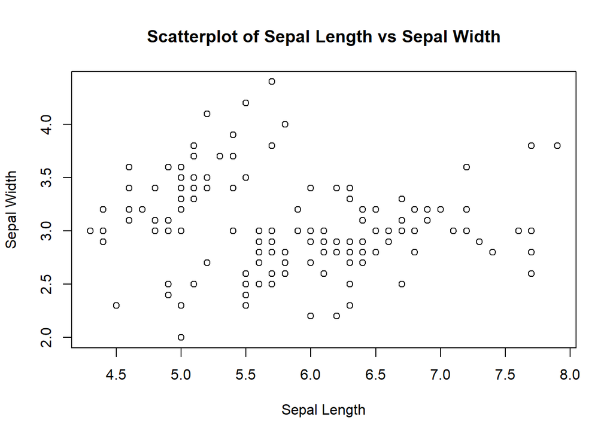

```r
plot(x = iris$Sepal.Length, y = iris$Sepal.Width,
     main = "Scatterplot of Sepal Length vs Sepal Width",
     xlab = "Sepal Length",
     ylab = "Sepal Width",
     pch = 21, # shape of the points
     col = "black")
```

- `plot()`: Creates a scatterplot of Sepal.Length (x-axis) vs. Sepal.Width (y-axis).
- `main`: Specifies the title of the plot.
- `xlab` and `ylab`: Label the x-axis and y-axis.
- `pch` = 21: Sets the shape of the points. Change the value for different shapes.
- `col = "black"`: Sets the color of the points.

#### Adding a regression line to above scatterplot.

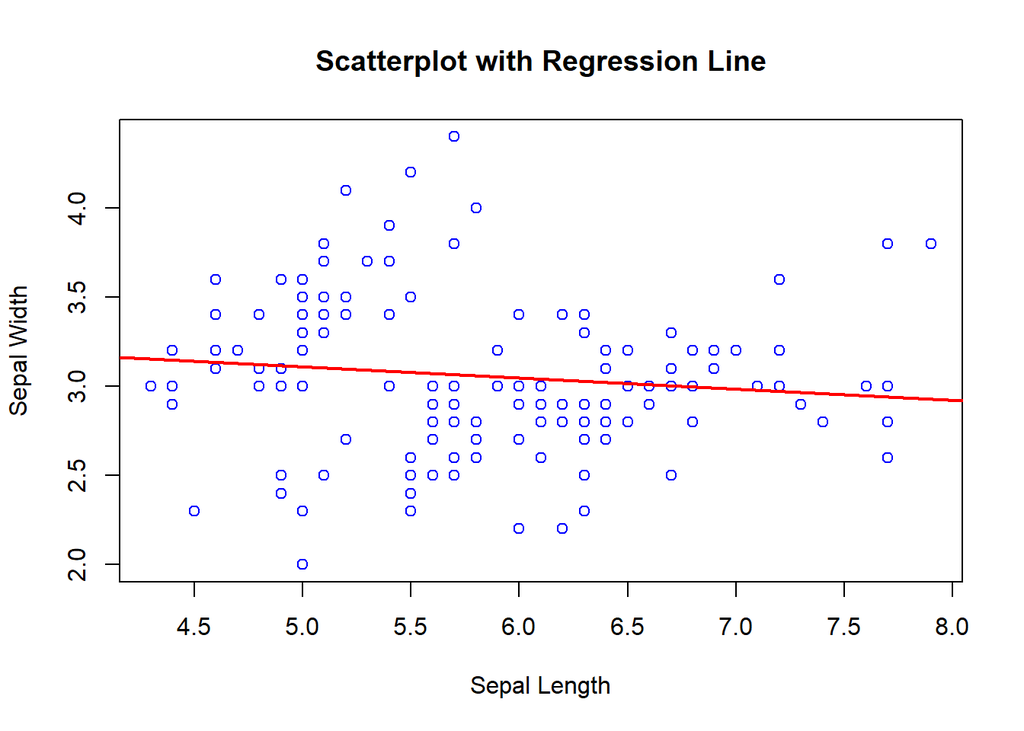

```r
plot(x = iris$Sepal.Length, y = iris$Sepal.Width,
     main = "Scatterplot with Regression Line",
     xlab = "Sepal Length",
     ylab = "Sepal Width",
     pch = 21,
     col = "blue")
abline(lm(Sepal.Width ~ Sepal.Length, data = iris), col = "red", lwd = 2)
```

#### Histogram

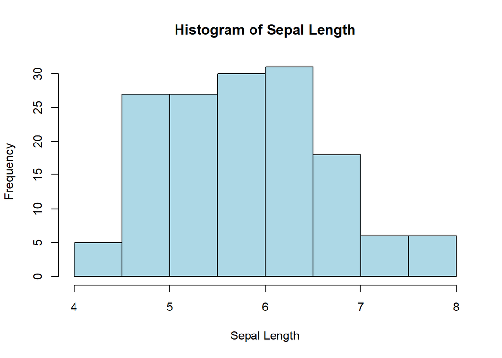

```r
hist(x = iris$Sepal.Length,
     main = "Histogram of Sepal Length",
     xlab = "Sepal Length",
     col = "lightblue",
     border = "black")
```

- `hist()`: Creates a histogram of Sepal.Length.
- `col`: Fills the bars with a light blue color.
- `border`: Sets the border color for the bars.

#### Overlaying a density curve to understand the distribution shape:

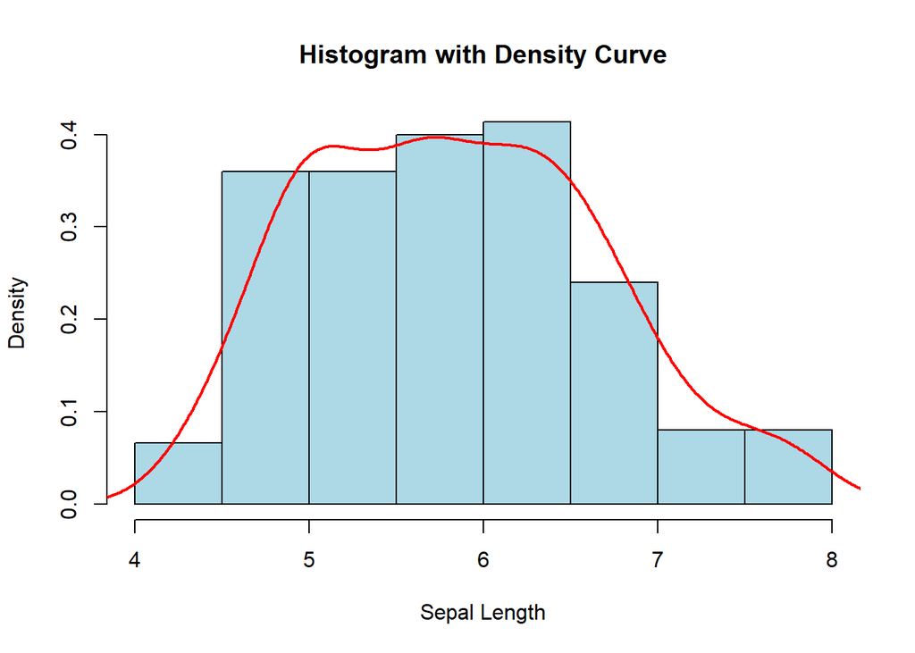

```r
hist(iris$Sepal.Length,
     main = "Histogram with Density Curve",
     xlab = "Sepal Length",
     col = "lightblue",
     border = "black",
     freq = FALSE)
lines(density(iris$Sepal.Length), col = "red", lwd = 2)
```

#### Barplot

Create a contingency table for the species

```r
#
species_counts <- table(iris$Species)
species_counts
```

```
##
##     setosa versicolor  virginica
##         50         50         50
```

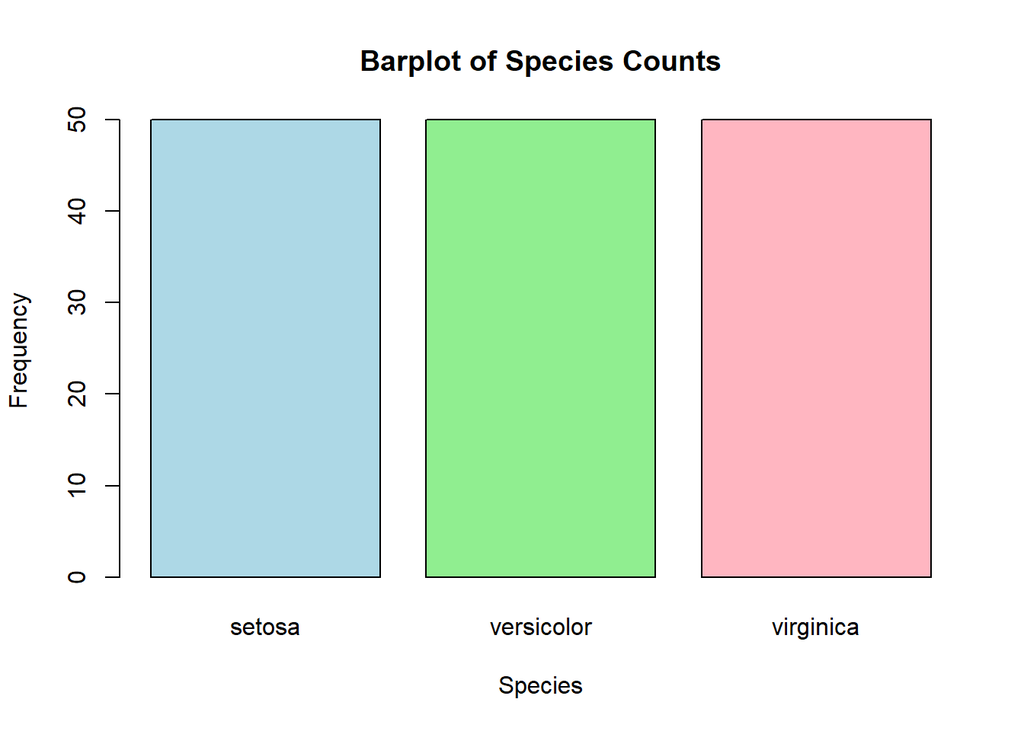

```r
# Create a bar plot
barplot(species_counts,
        main = "Barplot of Species Counts",
        xlab = "Species",
        ylab = "Frequency",
        col = c("lightblue", "lightgreen", "lightpink"),
        border = "black")
```

- `table(iris$Species)`: Generates a frequency table for the Species column.
- `barplot()`: Creates a barplot of the species counts.

#### Adding values above the bars for better clarity:

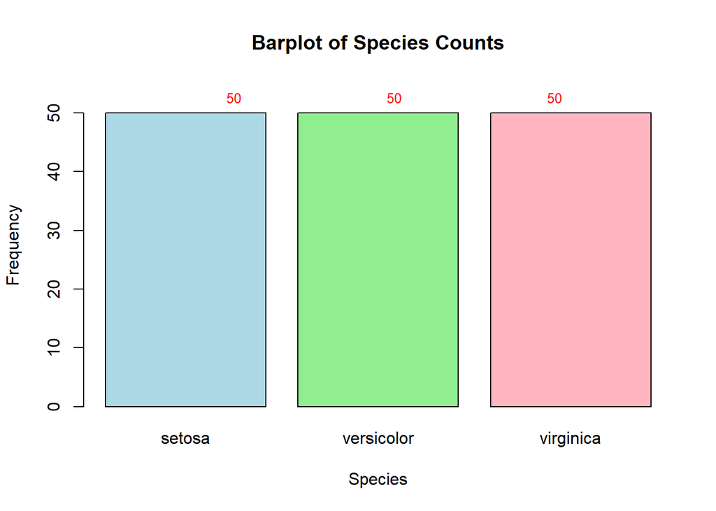

```r
barplot(species_counts,
        main = "Barplot of Species Counts",
        xlab = "Species",
        ylab = "Frequency",
        col = c("lightblue", "lightgreen", "lightpink"),
        border = "black",
        ylim = c(0, max(species_counts) + 5))
text(x = 1:3, y = species_counts, labels = species_counts, pos = 3, cex = 0.8, col = "red")
```

#### Boxplot

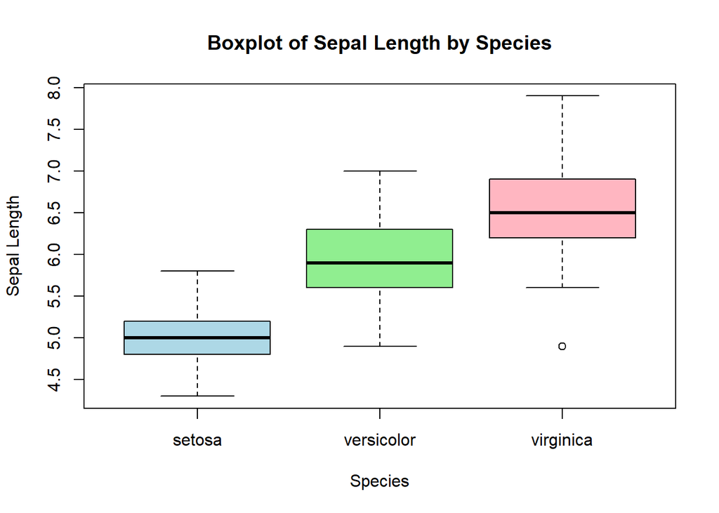

```r
boxplot(Sepal.Length ~ Species, data = iris,
        main = "Boxplot of Sepal Length by Species",
        xlab = "Species",
        ylab = "Sepal Length",
        col = c("lightblue", "lightgreen", "lightpink"),
        border = "black")
```

- `Sepal.Length ~ Species`: Groups Sepal.Length by Species for the boxplot.
- The boxplot shows the median, interquartile range (IQR), and potential outliers for each species.

### 8. Using `ggplot2` for Data Visualization

ggplot2 is part of the tidyverse collection of R packages and is a powerful library for creating advanced and aesthetic visualizations. It follows the grammar of graphics, which involves mapping data to visual properties (aesthetics) and adding geometric objects (geoms) to represent data points.

#### A. Histogram with `ggplot2`

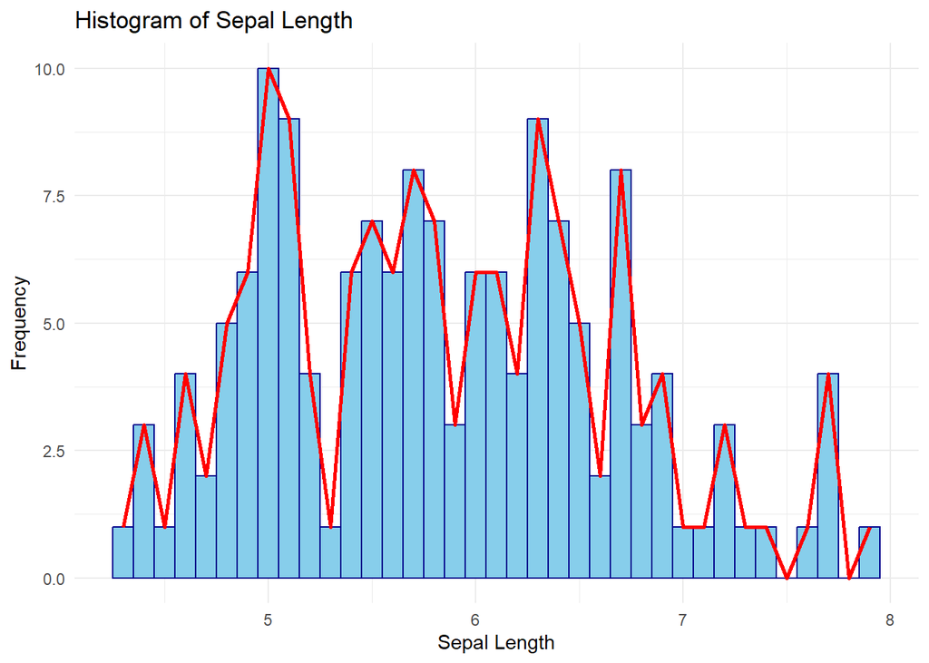

```r
ggplot(
  data = iris,
  aes(
    x = Sepal.Length
  )
) +
  geom_histogram(binwidth = 0.1,  fill = "skyblue", color = "darkblue") +  # Binwidth determines bar width
  geom_line(stat = "bin", binwidth = 0.1, color = "red", size = 1) +
  labs(
    title = "Histogram of Sepal Length",
    x = "Sepal Length",
    y = "Frequency"
  ) +
  theme_minimal()
```

#### B. Density Plot

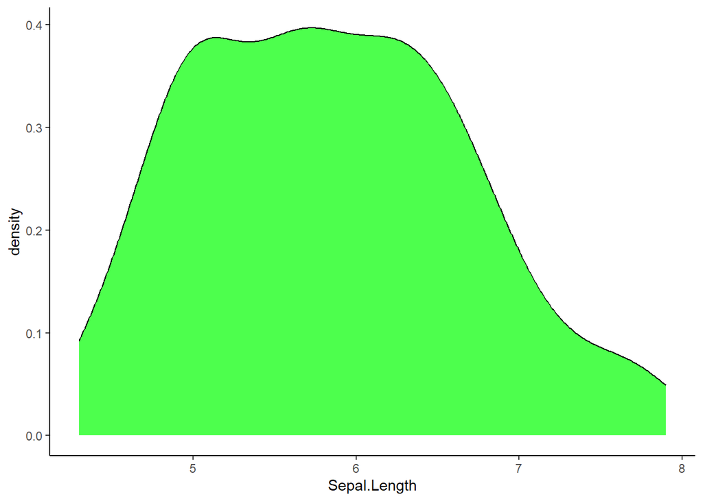

```r
# Overall density
ggplot(
  data = iris,
  aes(x = Sepal.Length)
) +
  geom_density(fill = "green", alpha = 0.7)+
  theme_classic()
```

- `geom_density()`: Creates a smoothed density plot of Sepal.Length.
- `fill = "green"`: Fills the density curve with green.
- `alpha = 0.7`: Adds transparency to the fill. 1 = opaque and 0 = transparent.
- `theme_classic()`: provides clean background with x and y lines.

#### C. Study species-specific distributions with color-coded density plots:

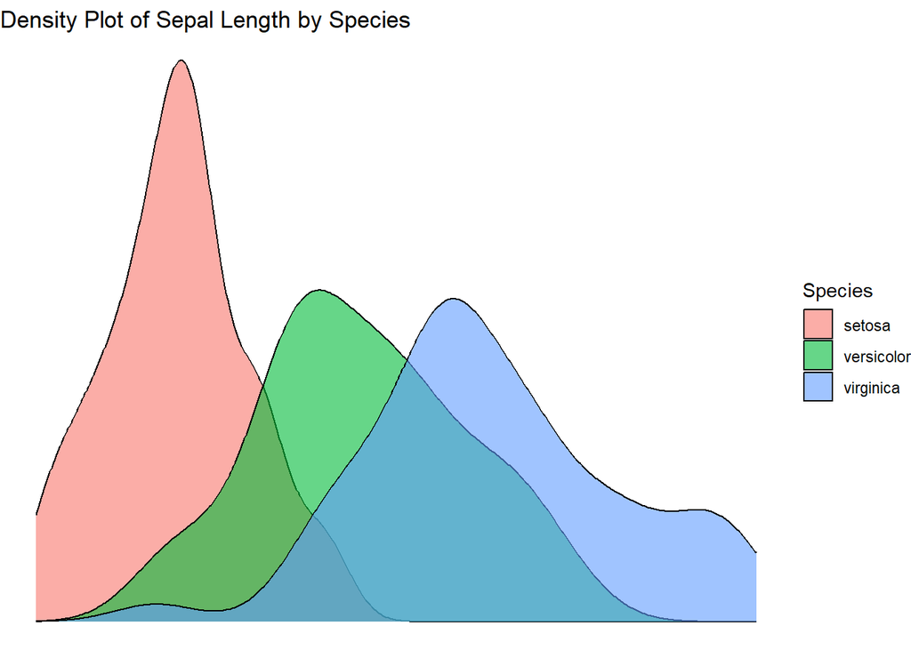

```r
ggplot(
  data = iris,
  aes(
    x = Sepal.Length,
    fill = Species
  )
) +
  geom_density(alpha = 0.6) +
  labs(
    title = "Density Plot of Sepal Length by Species",
    x = "Sepal Length",
    y = "Density"
  ) +
  theme_void()
```

`theme_void()` gives nothing but graph and its legend.

#### D. Scatterplot

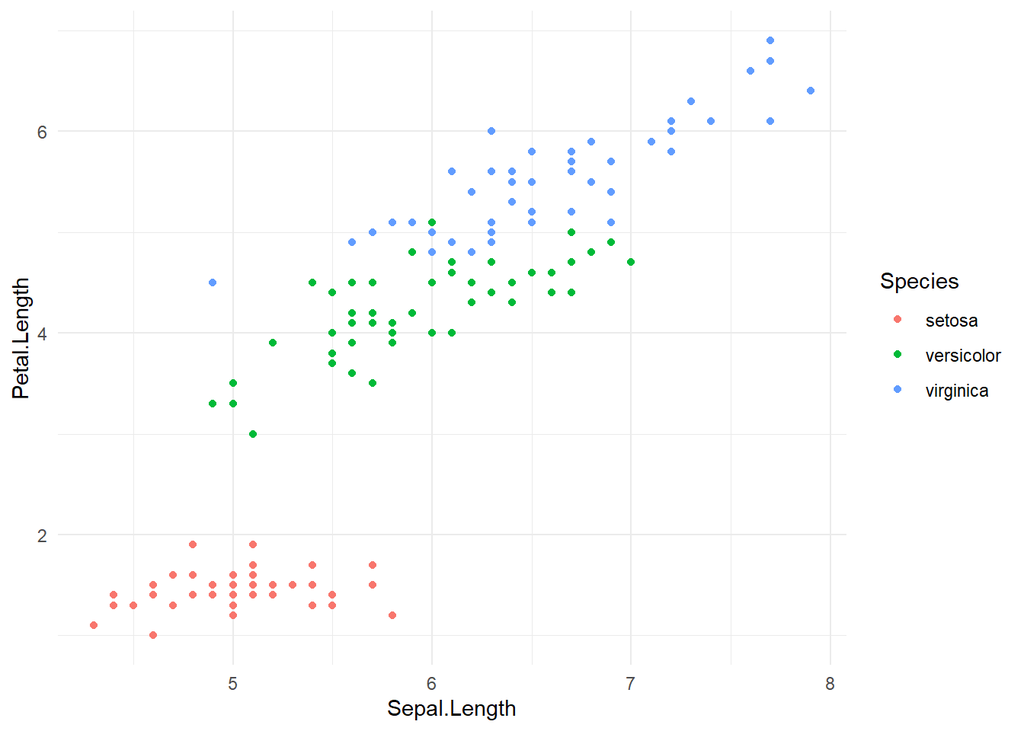

```r
ggplot(
  data = iris,
  aes(
    x = Sepal.Length,
    y = Petal.Length
  )
) +
  geom_point(
    aes(color = Species)
  )+
  theme_minimal()
```

- `aes(x = Sepal.Length, y = Petal.Length)`: Maps Sepal.Length to the x-axis and Petal.Length to the y-axis.
- `geom_point(aes(color = Species))`: Creates a scatterplot with points colored by Species.
- `theme_minimal()`: Yet another default theme present in ggplot2 package.

#### E. Boxplot

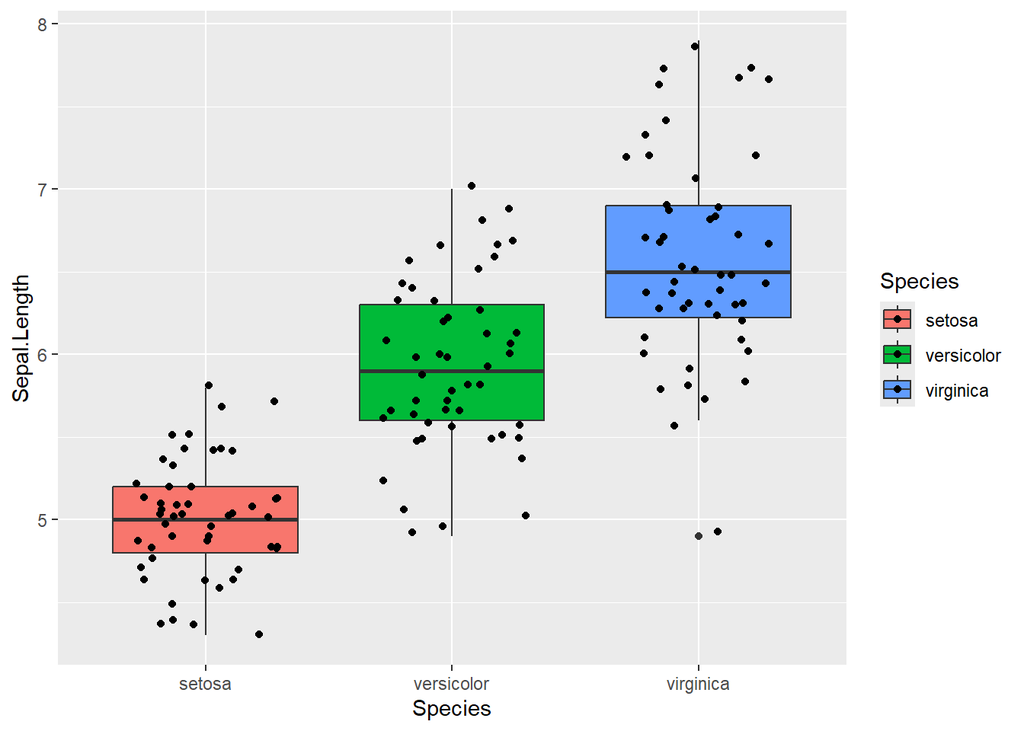

```r
ggplot(
  data = iris,
  aes(
    x = Species,
    y = Sepal.Length,
    fill = Species
  )
) +
  geom_boxplot() +
  geom_jitter(
    width = 0.3,
    alpha = 1
  )
```

- `geom_boxplot()`: Creates a boxplot for Sepal.Length grouped by Species.
- The box shows the median, interquartile range (IQR), and potential outliers.
- `geom_jitter(width = 0.3)`: Adds scattered data points around the boxplot to display data distribution.
- `width = 0.3`: Controls the spread of jitter points.
- `alpha = 1`: Sets the transparency of the points (fully opaque in this case).

#### F. Density Plot for a Specific Species

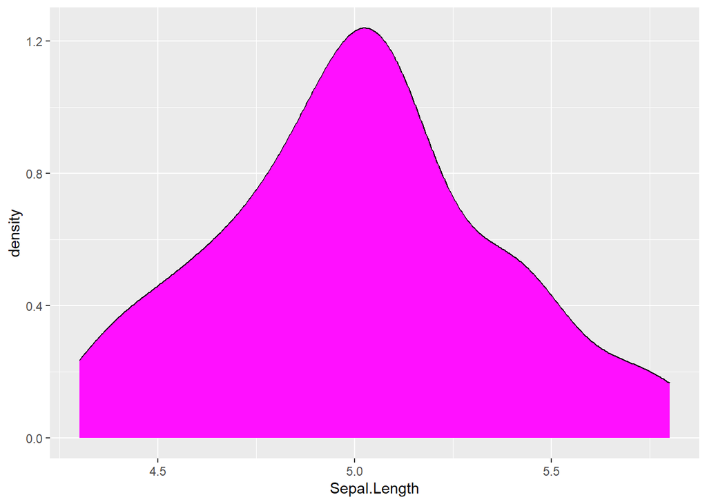

```r
# for setosa. Using the default filtering function in R.
ggplot(
  data = iris[iris$Species == "setosa", ],
  aes(
    x = Sepal.Length
  )
) +
  geom_density(fill = "#ff10ff")  # Color is specified by hex color code.
```

**Viewing the unique dataset in the column `Species`**

```r
unique(iris$Species)
```

```
## [1] setosa     versicolor virginica
## Levels: setosa versicolor virginica
```

##### Plotting the graph only for species versicolor.

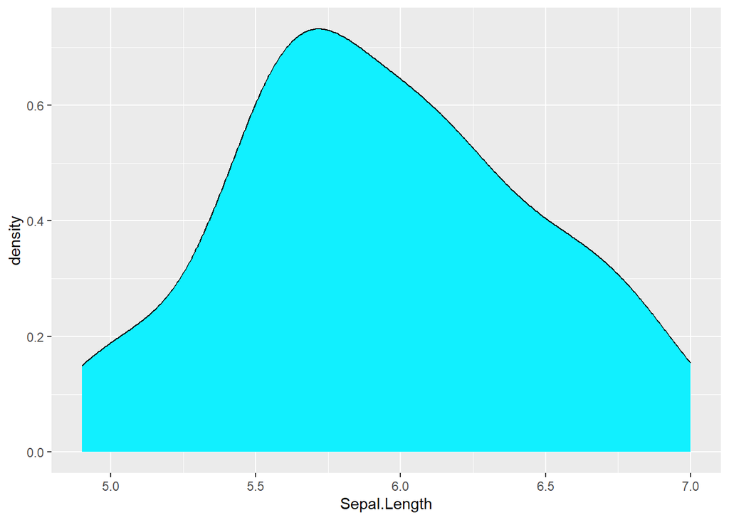

```r
# for versicolor  Using the default filtering function in R.
ggplot(
  data = iris[iris$Species == "versicolor", ],
  aes(
    x = Sepal.Length
  )
) +
  geom_density(fill = "#11f0ff")  # Color is specified by hex color code.
```

##### Plotting the graph only for species virginica.

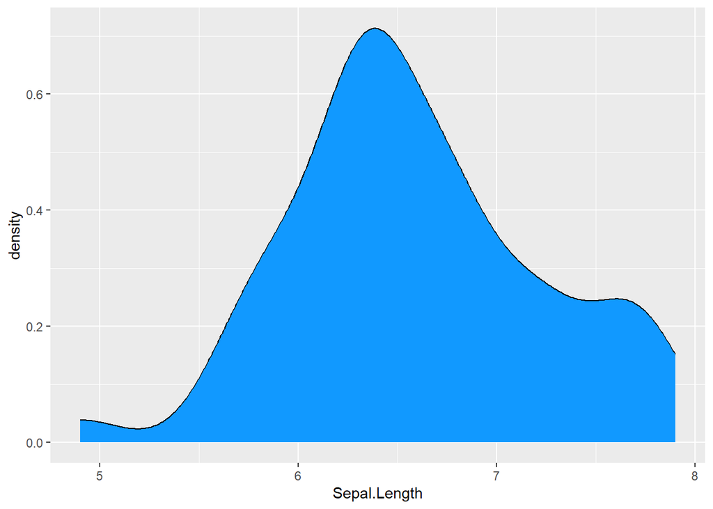

```r
# for virginica  Using the default filtering function in R.
ggplot(
  data = iris[iris$Species == "virginica", ],
  aes(
    x = Sepal.Length
  )
) +
  geom_density(fill = "#1199ff")  # Color is specified by hex color code.
```